# Cyclistic Case Study: Ride Analysis for Stakeholders

Gabriela Olivera

2025-12-03

## Executive Summary

The purpose of this case study is to analyse **how annual members and casual riders use Cyclistic bikes differently**, providing actionable insights for stakeholders.

**Key questions addressed**:

- What are the differences in ride duration and frequency between **Casual** and **Annual** users?
- How does usage vary by **weekday vs weekend**, day of the week, month, and hour of day?
- What recommendations can be made for **fleet management, marketing, and operational planning?**

## Data Overview

The dataset combines Cyclistic trip data for Q1 2019 and Q1 2020.

- Rows: Each row represents a single bike ride.
- Columns: Ride ID, start/end times, user type, ride duration, day of week, month, start hour.
- **Notes**:
  - Some columns contain NA values (e.g., rideable_type or columns only present in 2019). These do not affect the main analysis.
  - Data is cleaned to remove invalid or extreme rides (ride length ≤0 or >24 hours).

## Load Dataset

```r
library(tidyverse)
# Load the full cleaned dataset
cyclistic_full <- read_csv("cyclistic_cleaned_Q1_2019_2020.csv")
# Create a smaller sample for knitting (20k rows)
cyclistic <- cyclistic_full %>% sample_n(20000)

# Optional: save the sample dataset for reference
write_csv(cyclistic, "cyclistic_sample.csv")
```

**Notes for stakeholders:**

- We are using a subset of 20,000 rides to make the report efficient and readable.
- The full dataset contains all rides from Q1 2019 and Q1 2020.
- All analyses and visualisations use this sample but reflect the overall trends.

## Data Cleaning & Preparation

The following transformations were applied to prepare the dataset for analysi:

- Column names were standardised for consistency (ride_id, started_at, ended_at, member_casual).
- Ride length was calculated in minutes for comparison purposes.
- Day of week, month, and start hour were extracted to analyse trends over time.
- Days were classified as **Weekday** or **Weekend**.
- Users were grouped into **Casual** (Customer + casual) and **Annual** (member + Subscriber) for clearer comparison.

### Quick Summary by User Type Group

This summary shows **average ride length and number of rides per user type**, giving a high-level view of usage patterns.

```r
# Quick summary of ride counts and average duration by user type
cyclistic %>%
  group_by(user_type_group) %>%
  summarise(
    num_rides = n(),
    avg_ride_length = mean(ride_length),
    .groups = "drop"
  )
```

```
## # A tibble: 2 × 3
##   user_type_group num_rides avg_ride_length
##   <chr>               <int>           <dbl>
## 1 Annual              18216            11.5
## 2 Casual               1784            36.8
```

**Notes / Stakeholder interpretation:**

- **Annual users** tend to take more frequent but shorter rides.
- **Casual users** take fewer rides but for longer durations.

## Exploratory Data Analysis (EDA)

### 1. Trips by Day Type (Weekday vs Weekend)

**Objective**: Compare usage patterns between **Casual** and **Annual** users on weekdays vs weekends.

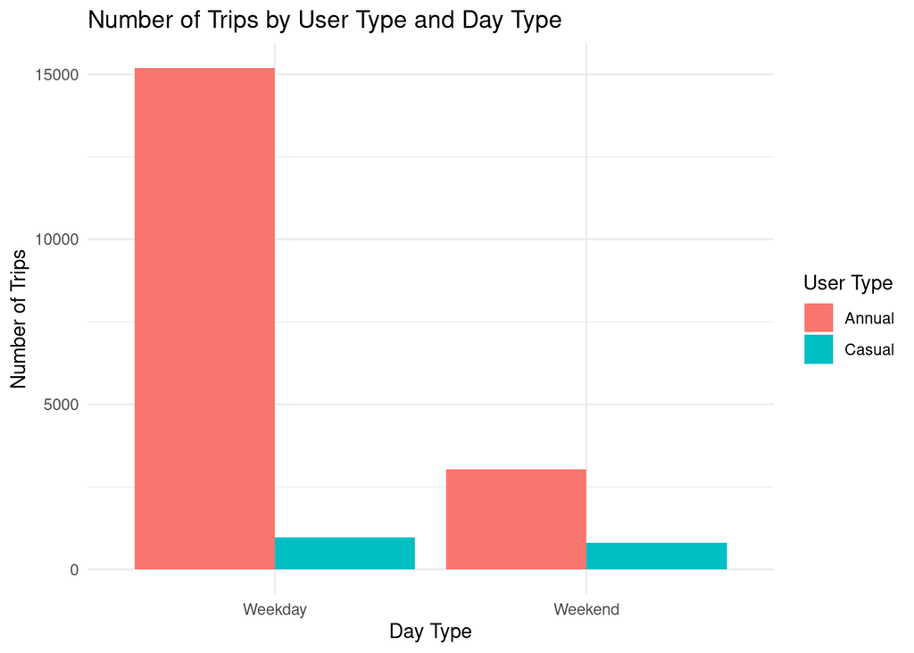

```r
# Number of trips by user type and day type
ggplot(cyclistic, aes(x = day_type, fill = user_type_group)) +
  geom_bar(position = "dodge") +
  labs(
    title = "Number of Trips by User Type and Day Type",
    x = "Day Type",
    y = "Number of Trips",
    fill = "User Type"
  ) +
  theme_minimal()
```

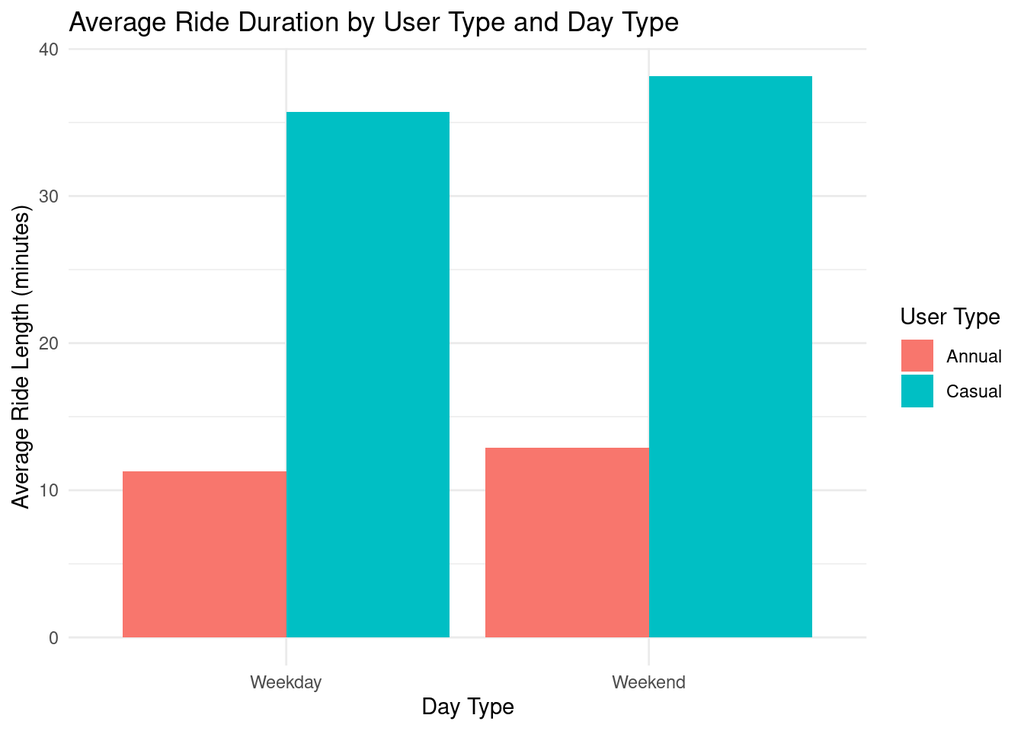

```r
# Average ride duration by user type and day type
ggplot(cyclistic, aes(x = day_type, y = ride_length, fill = user_type_group)) +
  stat_summary(fun = mean, geom = "bar", position = "dodge") +
  labs(
    title = "Average Ride Duration by User Type and Day Type",
    x = "Day Type",
    y = "Average Ride Length (minutes)",
    fill = "User Type"
  ) +
  theme_minimal()
```

#### Stakeholder Observations:

- **Casual riders** show higher activity on weekends and tend to take **longer rides**.
- **Annual riders** ride mostly on weekdays, reflecting **commuting patterns**.

### 2. Trips by Day of the Week

**Objective**: Understand how bike usage varies across the week for **Casual** vs **Annual** users.

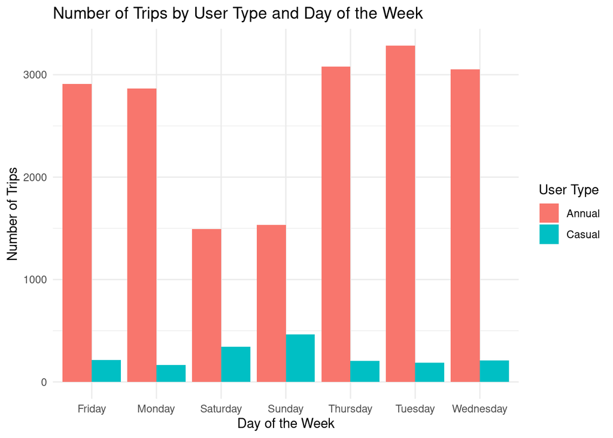

```r
ggplot(cyclistic, aes(x = day_of_week, fill = user_type_group)) +
geom_bar(position = "dodge") +
labs(
title = "Number of Trips by User Type and Day of the Week",
x = "Day of the Week",
y = "Number of Trips",
fill = "User Type"
) +
theme_minimal()
```

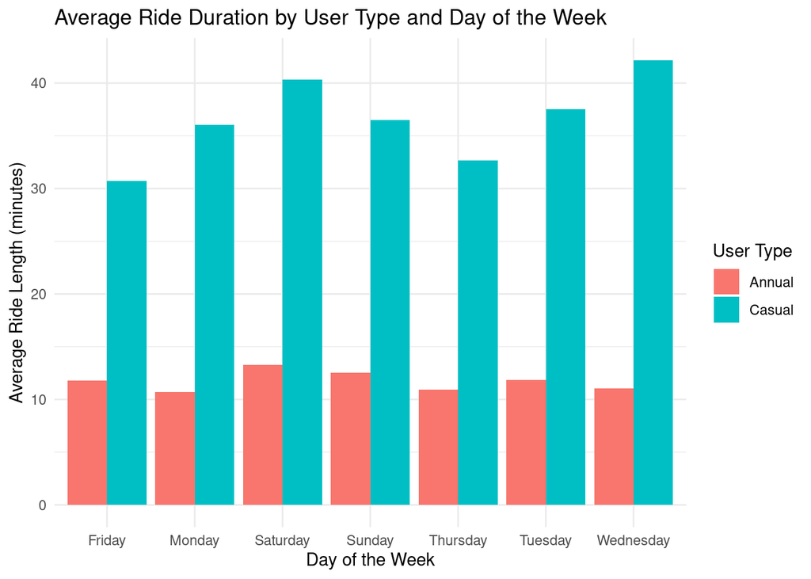

```r
ggplot(cyclistic, aes(x = day_of_week, y = ride_length, fill = user_type_group)) +
stat_summary(fun = mean, geom = "bar", position = "dodge") +
labs(
title = "Average Ride Duration by User Type and Day of the Week",
x = "Day of the Week",
y = "Average Ride Length (minutes)",
fill = "User Type"
) +
theme_minimal()
```

#### Insights:

- **Casual riders** peak on **Saturday** and **Sunday**.
- **Annual riders** show steady **weekday** usage with **slight peaks mid-week**.

### 3. Monthly Trends

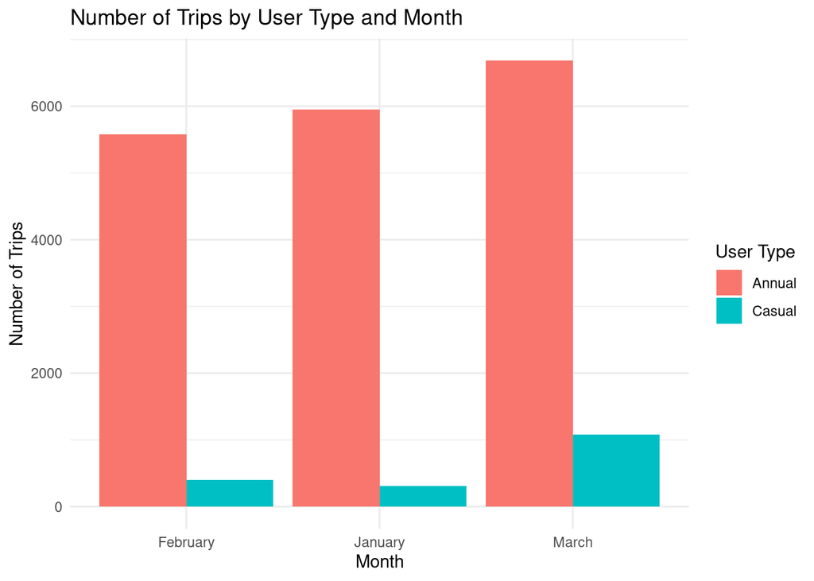

```r
ggplot(cyclistic, aes(x = month, fill = user_type_group)) +
geom_bar(position = "dodge") +
labs(
title = "Number of Trips by User Type and Month",
x = "Month",
y = "Number of Trips",
fill = "User Type"
) +
theme_minimal()
```

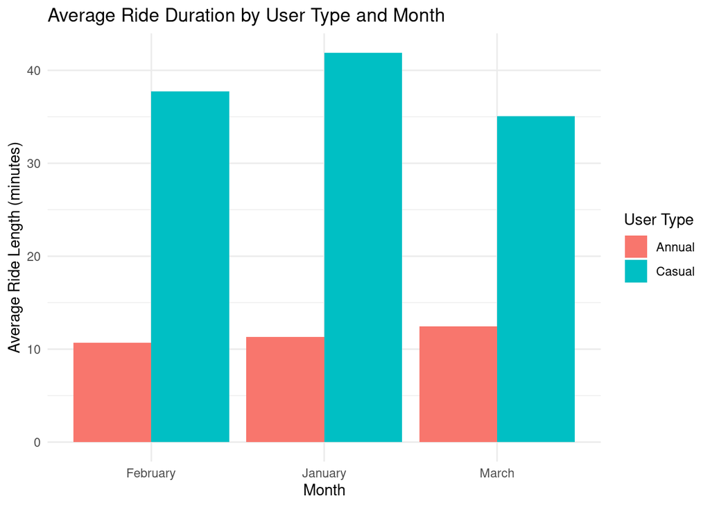

```r
ggplot(cyclistic, aes(x = month, y = ride_length, fill = user_type_group)) +
stat_summary(fun = mean, geom = "bar", position = "dodge") +
labs(
title = "Average Ride Duration by User Type and Month",
x = "Month",
y = "Average Ride Length (minutes)",
fill = "User Type"
) +
theme_minimal()
```

#### Observations:

- **Both groups** ride more in **March**.
- **Casual riders** show stronger **seasonal increase**.

### 4. Hour-of-Day Analysis

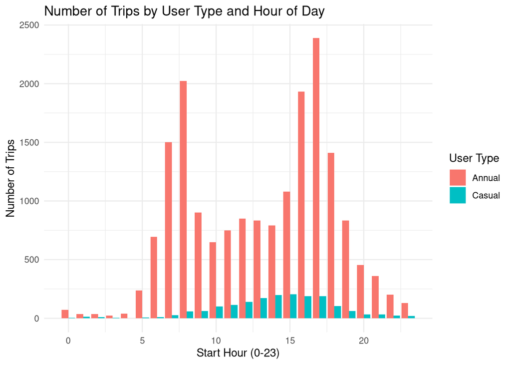

```r
# Number of trips by user type and hour of the day
ggplot(cyclistic, aes(x = start_hour, fill = user_type_group)) +
  geom_bar(position = "dodge") +
  labs(
    title = "Number of Trips by User Type and Hour of Day",
    x = "Start Hour (0-23)",
    y = "Number of Trips",
    fill = "User Type"
  ) +
  theme_minimal()
```

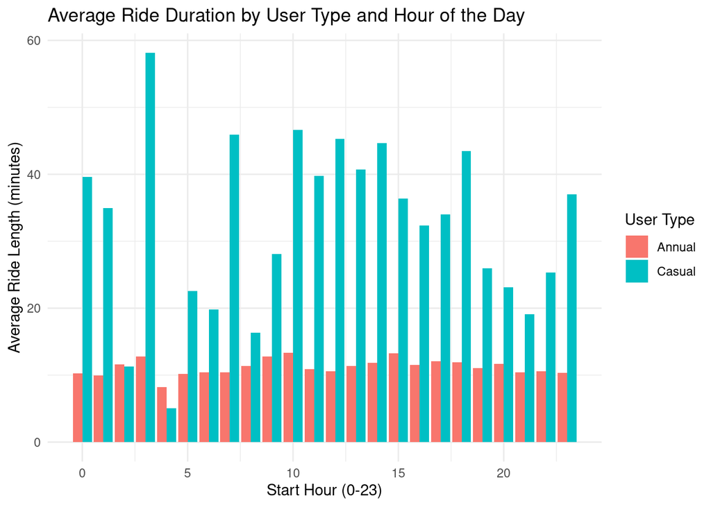

```r
# Average ride duration by user type and hour of the day
ggplot(cyclistic, aes(x = start_hour, y = ride_length, fill = user_type_group)) +
  stat_summary(fun = mean, geom = "bar", position = "dodge") +
  labs(
    title = "Average Ride Duration by User Type and Hour of the Day", # ¡CORRECCIÓN AQUÍ!
    x = "Start Hour (0-23)",
    y = "Average Ride Length (minutes)",
    fill = "User Type"
  ) +
  theme_minimal()
```

## Key Insights

### 1. Usage Differences:

- Annual riders: more frequent rides, shorter duration (~11–12 min).
- Casual riders: fewer rides, longer duration (~36–41 min).

### 3. Day-of-Week Patterns:

- Annual: steady weekdays.
- Casual: peaks on Saturday/Sunday.

### 5. Annual: commute peaks.

- Casual: late morning and afternoon recreational use.

## Recommendations

**Fleet Management**:

- Allocate more bikes to **central hub stations** during Annual riders’ peak commuting hours: 7:00-9:00 a.m. and 4:00-6:00 p.m. (Monday to Friday).

**Marketing**:

- Shift focus from general promotion to **Annual Membership Conversion**.
- Incentivise **Casual riders** by promoting the cost savings and convenience of short, routine weekday commutes.
- Offer special weekend perks (e.g., discounted day passes) to convert current weekend users.

**Seasonal Planning**:

Prepare for the strong seasonal surge (Q1 trend analysis). **Initiate conversion campaigns and fleet rotation in March** to capitalise on the increasing number of Casual riders transitioning into the spring season.

## Data Availability

```r
write_csv(cyclistic, "cyclistic_cleaned_Q1_2019_2020.csv")
```

## Interactive Data Visualisation

The final recommendations are supported by the interactive Tableau Dashboard, which allows stakeholders to filter the usage data by user type, day, and time.

**Click here to view the full interactive dashboard:** [https://public.tableau.com/app/profile/gabriela.olivera4636/viz/CyclisticQ1UsageStrategyDashboard/ExecutiveSummary]